# MSDM5051 Tutorial 3 - Sorting

## Contents

1. Sorting Algorithms
2. Heap
3. Practice

# 1. Sorting Algorithms

According to their nature, I have divided them into 4 groups:

- Elementary
- Divide and conquer
- Binary tree
- Operational

## 1.1. Elementary sorting

Elementary because they only involve comparing and swapping different elements in the array. The slowest, but require the least memeory allocation.

- **Insertion sort**:
  - Begin with the 2nd element. Compare its value to all its previous element.
  - If any of its previous element is found larger, insert it before that element.
  - Move on, begin with the 3rd element and repeat.

```python
def insertion_sort(array):
    n = len(array)

    for i in range(1,n):    # Loop of which element i to begin with

        temp = array[i]     # save the value of the current element (i)

        for j in range(i):             # search from the start or the end of the array does not matter much
                                       # (Note that the array before current element is already sorted from last loop of i)
            if array[j] > array[i]:    # find at which position (j) the value becomes bigger than the current element (i)

                array[j+1:i+1] = array[j:i]    # shift the whole segment from i to j by 1 index towards the end of the array
                array[j] = temp                # "insert" the current element's value at the emptied position

    return array
```

- **Bubble sort**:
  - Scan through the array from the end back to the 2nd element. Each element being scanned is compared with its previous element.
  - If it is smaller than its previous element, swap their positions. In this way, smaller element is brought to the front in every cycle.
  - Move on, repeat the scanning with ending at the 3rd element.

```python
def bubble_sort(array):
    n = len(array)

    for i in range(n-1):    # Loop of which position i to end at

        for j in range(n-1, i, -1):    # scan from the end back to the i element

            if array[j]<array[j-1]:                            # compare each element with the element before it
                array[j-1], array[j] = array[j], array[j-1]    # swap position if it is smaller than the element before it

    return array
```

## 1.2. Divide & Conquer

The given array is recursively divided into smaller arrays.

- **Quicksort**:
  - Recursively divide into pivot element + 2 sub-arrays. Elements in sub-arrays are chosen by comparison (larger/smaller) to pivot.
  - When subdivision is not possible anymore (i.e. sub-array length = 1), re-joining the sorted sub-arrays and pivot returns a sorted array.

```python
def quicksort(array):

    if len(array) < 2:    # stopping condition: no need to sort if array length is 1
        return array

    pivot = array[0]                               # for convenience, choose pivot as the first element
    left = [i for i in array[1:] if i <= pivot]    # element smaller than pivot is copied to the left array
    right = [i for i in array[1:] if i > pivot]    # element larger than pivot is copied to the right array

    return quicksort(left) + [pivot] + quicksort(right)
```

- **Mergesort**
  - Recursively divide into 2 sub-arrays of similar length.
  - When subdivision is not possible anymore, merge the sub-arrays by picking out their elements in order and comparing.

```python
def mergesort(array):

    if len(array) < 2:    # stopping condition: no need to sort if array length is 1
        return array

    mid = (len(array) + 1) // 2         # locate the middle element to bisect the array into 2 sub-arrays
    sub1 = mergesort(array[:mid])
    sub2 = mergesort(array[mid:])

    return ordered_merge(sub1, sub2)    # merge the 2 sub-arrays at the end



def ordered_merge(a1, a2):
    n = len(a1+a2)
    indx1, indx2 = 0, 0             # initialize 2 index to be followed along the 2 sub-arrays during merging
    result = [None]*n     # initialize an empty array for filling in the merged result

    while indx1 < len(a1) and indx2 < len(a2):    # merging process, similar to demo in lecture
        if a1[indx1] < a2[indx2]:
            result[indx1+indx2] = a1[indx1]
            indx1 += 1
        else:
            result[indx1+indx2] = a2[indx2]
            indx2 += 1

    # After the merging, one of the array will become empty first and the other will still have some remaining elements
    # the remaining elements should be all larger than those already filled in the result array
    # so they are appended at the end

    if indx1 == len(a1):                      # if array1 is the one becomes empty first
        result[len(a1)+indx2:] = a2[indx2:]   # fill the remaining entries with elements remain in array2
    else:
        result[len(a2)+indx1:] = a1[indx1:]   # else fill the remaining entries with elements remain in array1

    return result
```

## 1.3. Binary trees

By first converting the array into a binary tree, we can enjoy more efficient array operations like search and insert. The types of trees are differed by their construction rules.

- **Heap**
- **AVL tree**
- **Red-black tree** (RBT)

See section 2 for heap. AVL and RBT are intrinsically sorted if they are created following their insertion/deletion rules.

## 1.4. Operational

They have linear complexity, due to that the ordering of elements are not relying on comparison on value, but operations on the elements. As a tradeoff there are restrictions in the input data (e.g. interger only) and require more computer memory.

- **Counting Sort** = Like making a histogram - assign a bin to each data and count their appearance at the end.
- **Radix Sort** = Like running each data through a decision tree, whose decision rules are based on the digits.

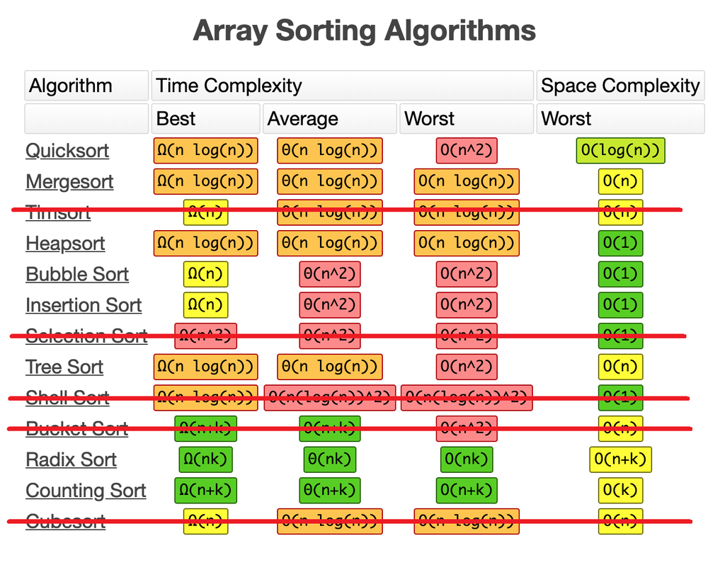

**Fig. 2** Complexity chart of different sorting algorithms. Retrieved from https://www.bigocheatsheet.com/.

# 2. Heap

## 2.1. Tree terminologies

Here gives a simple summary to the terminologies of trees:

```python
class Node:
    def __init__(self, data, left_node=None, right_node=None):
        self.data = data
        self.left = left_node
        self.right = right_node

class BinaryTree:
    def __init__(self, root=None):
        self.root = root
```

- **Binary search tree** (BST) = Binary tree by the data carried by each node satisfies the rules:
  - All the data values in its left sub-tree are smaller than the data value in itself.
  - All the data values in its right sub-tree are larger than the data value in itself.

    Due to this, a binary search tree is also called an **ordered binary tree**. These rules are maintained via algorithms for nodes insertion/deletion (as you can see from the lengthy codes about BST insertion/deletion in the lecture nodes).

## 2.2. Heap's property

Heap is a special kind of binary tree (NOT binary search tree), that satisfies the following rule depends on if it is max-heap (or min-heap):

1. The value of each node is greater (smaller) than or equal to the data values stored in each of its children.
   - Thus the root node is always the max (min) of the tree.
   - This is where the difference of a heap from binary search tree is - The left/right children of a heap node are not related.
1. The tree is perfectly balanced, and the leaves in the last level are all in the leftmost positions.
   - So the height of heaps is always $O(\log n)$.

### 2.2.1. Heap as priority queue

Every heap can be read into an array from the order of top-bottom and left-right. For example, a max heap:

[figure not shown]

**Fig. 1** Converting heap to array.

The value of the result array satisfy the property:

$$ \text{heap_array}[i] \geq \text{heap_array}[2i+2] \qquad \text{for } \frac{n-2}{2} \geq i \geq 0 $$

Note that in a max-heap **all the elements with larger value have a high probability to be at the top levels** (even though it is not sorted!). This makes searching very efficient if we are only interested in those largest elements. Therefore heap is also commly used as a priority queue - elements with higher priorities (values) go first.

### 2.2.2. Array to heap

On the contrary, not every array satisfies the heap property. Here are the steps to convert an array into one that satisfy the max-heap (or min-heap) property:

1. Start a `for` loop from the end of the array, i.e. the right-most node at the tree's bottom level.
2. Inside the for loop, run `max_heapify()` (or `min_heapify()`) on each element of the array.

Note that although the `heapify` operations are described using the "parent-child-node" language, the only thing it does is swapping the original array's element - which can be done without converting the array elements into `Node`-like objects. So in the codes from lecture, you won't see things like `.left`/`.right`... but instead these nodes' relation are traced by array index.

[figure not shown]

**Fig. 2** Equivalent array operations in to node operations in heapify.

```python
# This is the code from lecture

class Heap():
    def __init__(self, array):
        self.heap = array
        self.length = len(array)
        self.build_max_heap()        # When declaring Heap(my_array), my_array will be re-ordered to satisfy the max-heap property

    ###########################################################################
    # These 3 functions are for tracing the parent-children relation using array index
    # We can check that if the current element's index in the array is i, then
    #
    # - its left child's index in the array = 2i+1
    # - its right child's index in the array = 2i+2
    # - its parent's index in the array = (i-1)/2 (round down)
    #
    # So in heapify, we can find a node's child/parent by array index, and we don't
    # need to convert the elements into nodes and access the relation by .left/.right/.parent

    def left(self, idx):
        pos = 2 * idx + 1
        return pos if pos < self.length else None

    def right(self, idx):
        pos = 2 * idx + 2
        return pos if pos < self.length else None

    def parent(self, idx):
        return (idx - 1) // 2 if idx > 0 else None


    ###########################################################################
    # A function to determine the index of the greater child of the current element
    def _greater_child(self, i):

        left, right = self.left(i), self.right(i)        # left and right are index of the element i's children
                                                         # None if not exist
        if left is None and right is None:
            return None
        elif left is None:
            return right
        elif right is None:
            return left
        else:
            return left if self.heap[left]>self.heap[right] else right


    ###########################################################################
    # These are the main steps to heapify an array

    def build_max_heap(self):

        last_to_heapify = self.parent(self.length - 1)
        for i in range(last_to_heapify, -1, -1):        # A for loop to starting from the end of the array to heapify every element
                                                        # But since leaves do not need to be heapified
            self.max_heapify(i)                         # we can start from the parent of the last leaf


    def max_heapify(self, i):

        greater_child = self._greater_child(i)         # get the array index of the greater child

        # stopping condition: no need to continue if either
        # - The current node is a leaf node, or
        # - Current node is larger than all its children. (This is guarenteed since all its children are already heapified once)

        if greater_child is not None and self.heap[greater_child] > self.heap[i]:

            # swap with array element corresponding to node's greater child and contin
            self.heap[i], self.heap[greater_child] = self.heap[greater_child], self.heap[i]

            # repeat procedure over the greater child
            self.max_heapify(greater_child)
```

### 2.2.3. Heapsort

An array that satisfies the max-heap (or min-heap) property can be fully sorted by the following steps:

1. Create an empty array for storing the sorted nodes.
2. Append the root node to the empty array for sorted nodes.
3. Swap root node with the last leaf (i.e. Swap first and last element in the array). **Then remove the original root node (i.e. the last element) from the array**.
4. Run `max_heapify` on the new root node.
5. Repeat step 2-4, but with the 2nd last leaf instead of the last leaf.

... and so on until the root node is reached. Again, these steps only involve swapping and can be performed solely via array operations.

```python
def heapsort(array):

        n = len(array)
        my_heap = Heap(array)    # turn the input array to output a heap object
                                 # by doing so, the elements are re-ordered to satisfy the max heap property
                                 # and also allow us to use the max_heapify function

        counter = len(array)     # for counting from the last node up to the first
        sorted_results = [None]*n     # for storing the sorted nodes

        while counter > 1:
            sorted_results[n-counter] = my_heap.heap[0]    # copy the root to the storage
            my_heap.heap[0], my_heap.heap[counter - 1] = my_heap.heap[counter - 1], my_heap.heap[0]

            my_heap.heap = my_heap.heap[:counter]    # exclude the original root before max_heapify
            my_heap.length = my_heap.length-1

            my_heap.max_heapify(0)
            counter -= 1

        sorted_results[-1] = my_heap.heap[0]    # copy the last element in the heap directly at the end

        return sorted_results
```

# 3. Practice

## 3.1. Natural sort

Natural sort is a version of mergesort that makes use of already-ordered sequences (called "runs"). For example `[6,7,8,3,4,1,11,12,13,2]` can be first cut into `[6,7,8]`, `[3,4]`, `[1,11,12,13]`, `[2]`, then merge `[6,7,8]` and `[3,4]`, `[1,11,12,13]` and `[2]`, and finally merge the two results to form the final array. Try to implement this algorithm.

```python
### Try it yourself. This is a variation of mergesort so you are allowed to use the ordered_merge() function.
```

## 3.2. Insertion sort in linked list

Insertion sort is easily adaptable to linked list since insertion in linked list is rather simple. Try to write a linked list version for insertion sort.

```python
# The definition of a linked list and its node are given to you

class Node:
    def __init__(self, data, next_node=None):
        self.data = data
        self.next = next_node

class SinglyLinkedList:
    def __init__(self, head=None):
        self.head = head

    def print_list(self):
        print_node = self.head
        while print_node is not None:
            print(print_node.data)
            print_node = print_node.next

    ###########################################################################
    # Finish the insertion_sort() function
    # the original array should be replaced by a sorted array

    def insertion_sort(self):


    ###########################################################################
```

```python
# For your testing

my_array = [9,2,25,4,8,7,2,1,15,4,29]

# convert into linked list
node_list = [Node(i) for i in my_array]
my_SLL = SinglyLinkedList(node_list[0])
for i, node in enumerate(node_list[:-1]):
    node.next = node_list[i+1]


my_SLL.insertion_sort()
my_SLL.print_list()
```

You may also check out these exercises and their solutions on LeetCode:

- [Problem 324 - Wiggle Sort II](https://leetcode.com/problems/wiggle-sort-ii/)
- [Problem 581 - Shortest Unsorted Continuous Subarray](https://leetcode.com/problems/shortest-unsorted-continuous-subarray/)
- [Problem 240 - Search a 2D Matrix II](https://leetcode.com/problems/search-a-2d-matrix-ii/)